# Autoregressive models

3 Jan 2024

## Topics for today

White noise

Random walks

Autoregressive (AR) models

Moving average (MA) models

Autoregressive moving average (ARMA) models

Using ACF & PACF for model ID

## White noise (WN)

A time series \(\{w_t\}\) is discrete white noise if its values are

1. independent
2. identically distributed with a mean of zero

## White noise (WN)

A time series \(\{w_t\}\) is discrete white noise if its values are

1. independent
2. identically distributed with a mean of zero

**Note**: the distributional form for \(\{w_t\}\) is flexible

## White noise (WN)

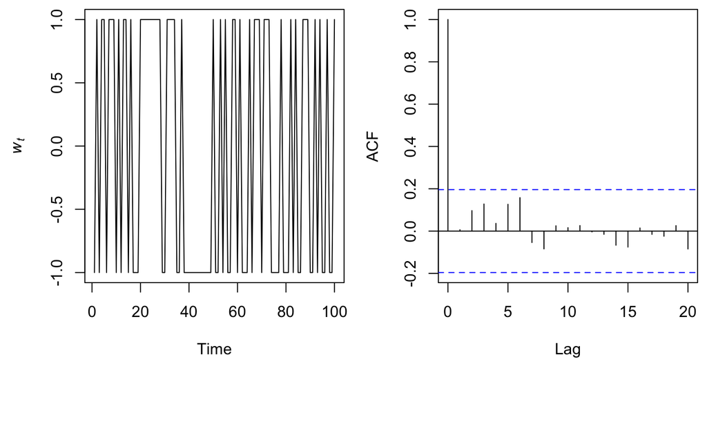

\(w_t = 2e_t - 1; e_t \sim \text{Bernoulli}(0.5)\)

## Gaussian white noise

We often assume so-called *Gaussian white noise*, whereby

\[ w_t \sim \text{N}(0,\sigma^2) \]

## Gaussian white noise

We often assume so-called *Gaussian white noise*, whereby

\[ w_t \sim \text{N}(0,\sigma^2) \]

where the following apply as well

autocovariance: \(\gamma_k = \begin{cases} \sigma^2 & \text{if } k = 0 \\ 0 & \text{if } k \geq 1 \end{cases}\)

autocorrelation: \(\rho_k = \begin{cases} 1 & \text{if } k = 0 \\ 0 & \text{if } k \geq 1 \end{cases}\)

## Gaussian white noise

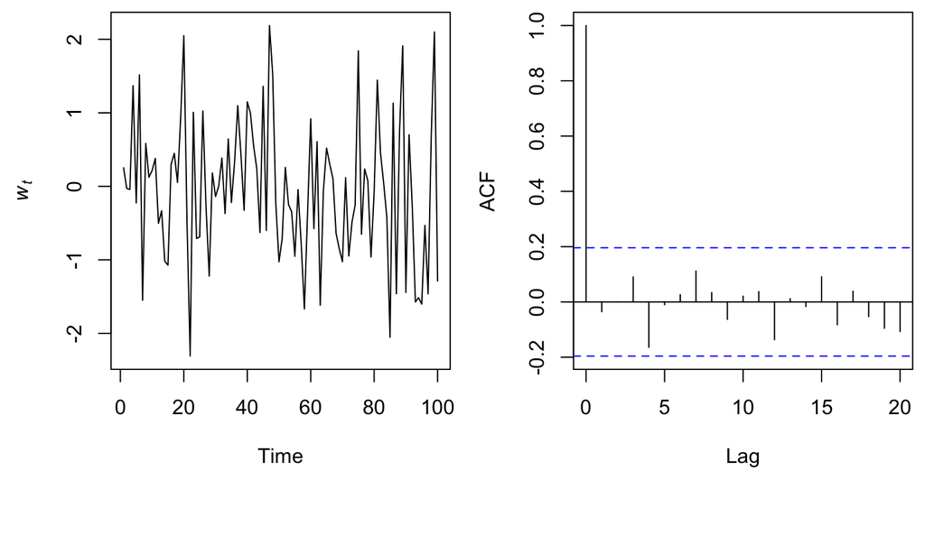

\(w_t \sim \text{N}(0,1)\)

## Random walk (RW)

A time series \(\{x_t\}\) is a random walk if

1. \(x_t = x_{t-1} + w_t\)
2. \(w_t\) is white noise

## Random walk (RW)

The following apply to random walks

mean: \(\mu_x = 0\)

autocovariance: \(\gamma_k(t) = t \sigma^2\)

autocorrelation: \(\rho_k(t) = \frac{t \sigma^2}{\sqrt{t \sigma^2(t + k) \sigma^2}}\)

## Random walk (RW)

The following apply to random walks

mean: \(\mu_x = 0\)

autocovariance: \(\gamma_k(t) = t \sigma^2\)

autocorrelation: \(\rho_k(t) = \frac{t \sigma^2}{\sqrt{t \sigma^2(t + k) \sigma^2}}\)

**Note**: Random walks are not stationary

## Random walk (RW)

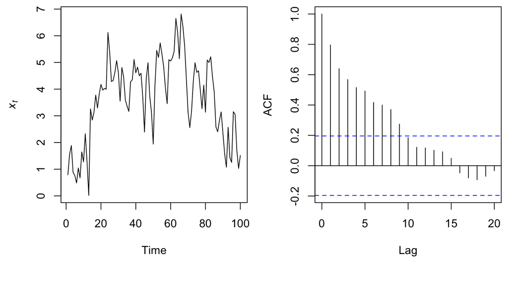

\(x_t = x_{t-1} + w_t~\) with \(~w_t \sim \text{N}(0,1)\)

## Random walk (RW)

**Of note**: Random walks are extremely flexible models and can be fit to many kinds of time series

## Biased random walk

A *biased random walk* (or *random walk with drift*) is written as

\[ x_t = x_{t-1} + u + w_t \]

where \(u\) is the bias (drift) per time step and \(w_t\) is white noise

## Biased random walk

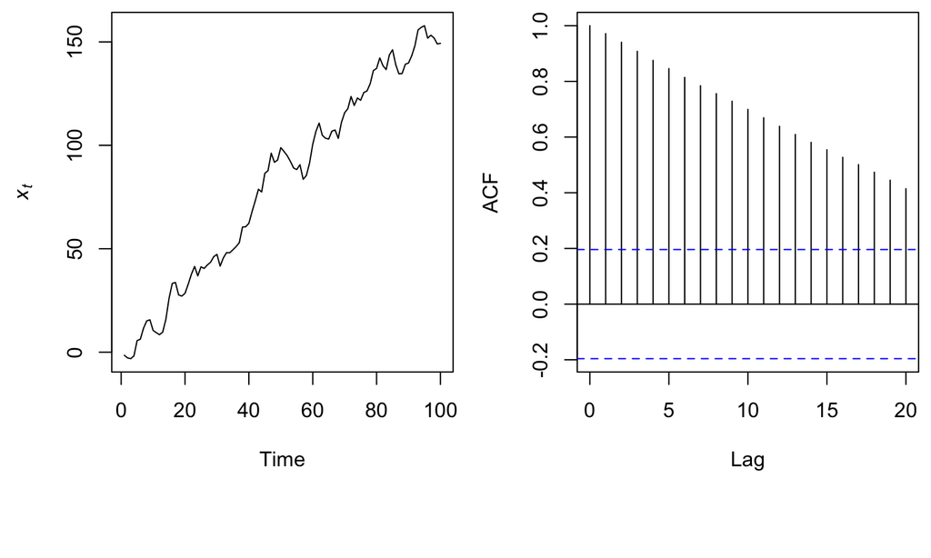

## Aside: Differencing a time series

Differencing can be thought of like a derivative for discrete time series

Differencing is simply subtracting a time-shifted version of a time series from itself

## Notation: Differencing a time series

We use the *difference operator* \(\nabla\) to indicate a differencing operation

## Differencing a biased random walk

First-differencing a biased random walk yields a constant mean (level) \(u\) plus white noise

\[ \begin{align} x_t &= x_{t-1} + u + w_t \\ &\Downarrow \\ \nabla (x_t &= x_{t-1} + u + w_t) \\ x_t - x_{t-1} &= x_{t-1} + u + w_t - x_{t-1} \\ x_t - x_{t-1} &= u + w_t \end{align} \]

## Differencing a biased random walk

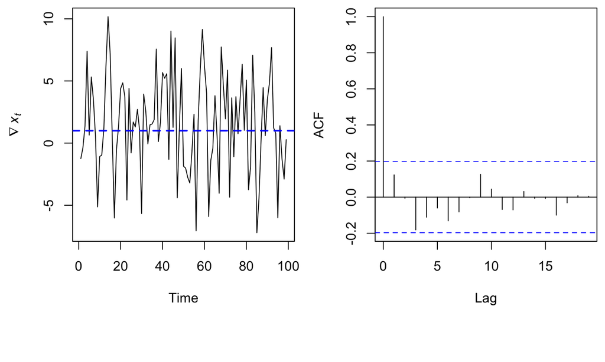

## Linear stationary models

## Linear stationary models

We saw previously that linear filters are a useful way of modeling time series

Here we extend those ideas to a general class of models call *autoregressive moving average* (ARMA) models

## Autoregressive (AR) models

Autoregressive models are widely used in ecology to treat a current state of nature as a function its past state(s)

## Autoregressive (AR) models

An *autoregressive* model of order *p*, or AR(*p*), is defined as

\[ x_t = \phi_1 x_{t-1} + \phi_2 x_{t-2} + \dots + \phi_p x_{t-p} + w_t \]

where we assume

1. \(w_t\) is white noise
2. \(\phi_p \neq 0\) for an order-*p* process

## Examples of AR(*p*) models

AR(1)

\(x_t = 0.5 x_{t-1} + w_t\)

AR(1) with \(\phi_1 = 1\) (random walk)

\(x_t = x_{t-1} + w_t\)

AR(2)

\(x_t = -0.2 x_{t-1} + 0.4 x_{t-2} + w_t\)

## Examples of AR(*p*) models

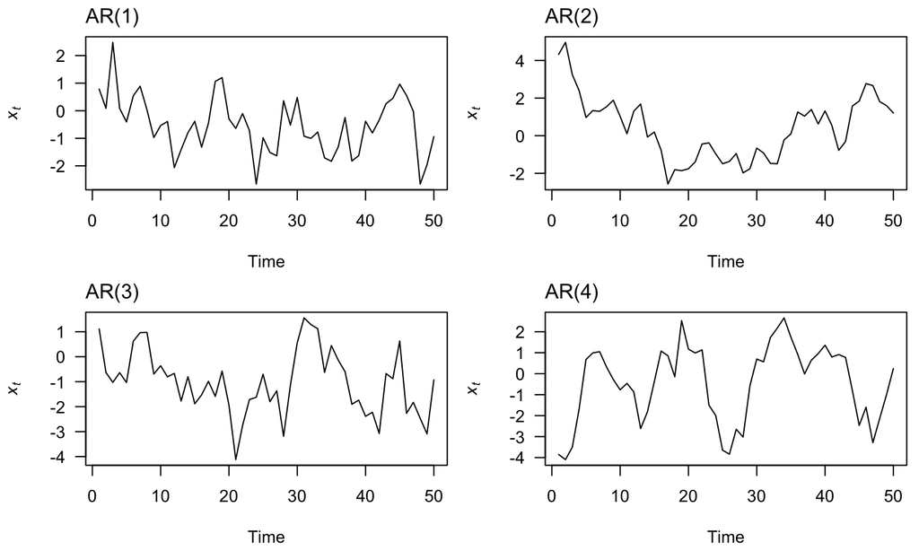

## Stationary AR(*p*) models

Recall that *stationary* processes have the following properties

1. no systematic change in the mean or variance
2. no systematic trend
3. no periodic variations or seasonality

## Stationary AR(*p*) models

Recall that *stationary* processes have the following properties

1. no systematic change in the mean or variance
2. no systematic trend
3. no periodic variations or seasonality

We seek a means for identifying whether our AR(*p*) models are also stationary

## Stationary AR(*p*) models

We can write out an AR(*p*) model using the backshift operator

\[ x_t = \phi_1 x_{t-1} + \phi_2 x_{t-2} + \dots + \phi_p x_{t-p} + w_t \\ \Downarrow \\ \begin{align} x_t - \phi_1 x_{t-1} - \phi_2 x_{t-2} - \dots - \phi_p x_{t-p} &= w_t \\ (1 - \phi_1 \mathbf{B} - \phi_2 \mathbf{B}^2 - \dots - \phi_p \mathbf{B}^p) x_t &= w_t \\ \phi_p (\mathbf{B}^p) x_t &= w_t \\ \end{align} \]

## Stationary AR(*p*) models

If we treat \(\mathbf{B}\) as a number (or numbers), we can out write the *characteristic equation* as

\[ \phi_p (\mathbf{B}) x_t = w_t \\ \Downarrow \\ \phi_p (\mathbf{B}^p) = 0 \]

To be stationary, **all roots** of the characteristic equation **must exceed 1 in absolute value**

## Stationary AR(*p*) models

For example, consider this AR(1) model from earlier

\[ x_t = 0.5 x_{t-1} + w_t \]

## Stationary AR(*p*) models

For example, consider this AR(1) model from earlier

\[ x_t = 0.5 x_{t-1} + w_t \\ \Downarrow \\ \begin{align} x_t - 0.5 x_{t-1} &= w_t \\ x_t - 0.5 \mathbf{B}x_t &= w_t \\ (1 - 0.5 \mathbf{B})x_t &= w_t \\ \end{align} \]

## Stationary AR(*p*) models

For example, consider this AR(1) model from earlier

\[ \begin{align} (1 - 0.5 \mathbf{B})x_t &= w_t \\ \Downarrow \\ 1 - 0.5 \mathbf{B} &= 0 \\ -0.5 \mathbf{B} &= -1 \\ \mathbf{B} &= 2 \\ \end{align} \]

This model is indeed stationary because \(\mathbf{B} > 1\)

## Stationary AR(*p*) models

What about this AR(2) model from earlier?

\[ x_t = -0.2 x_{t-1} + 0.4 x_{t-2} + w_t \\ \]

## Stationary AR(*p*) models

What about this AR(2) model from earlier?

\[ x_t = -0.2 x_{t-1} + 0.4 x_{t-2} + w_t \\ \Downarrow \\ \begin{align} x_t + 0.2 x_{t-1} - 0.4 x_{t-2} &= w_t \\ x_t + 0.2 \mathbf{B} x_t - 0.4 \mathbf{B}^2 x_t &= w_t \\ (1 + 0.2 \mathbf{B} - 0.4 \mathbf{B}^2)x_t &= w_t \\ \end{align} \]

## Stationary AR(*p*) models

What about this AR(2) model from earlier?

\[ (1 + 0.2 \mathbf{B} - 0.4 \mathbf{B}^2)x_t = w_t \\ \Downarrow \\ 1 + 0.2 \mathbf{B} - 0.4 \mathbf{B}^2 = 0 \\ \Downarrow \\ \mathbf{B}_1 \approx -1.35 ~ \text{and} ~ \mathbf{B}_2 \approx 1.85 \]

## What about random walks?

Consider our random walk model

\[ x_t = x_{t-1} + w_t \]

## What about random walks?

Consider our random walk model

\[ x_t = x_{t-1} + w_t \\ \Downarrow \\ \begin{align} x_t - x_{t-1} &= w_t \\ x_t - 1 \mathbf{B}x_t &= w_t \\ (1 - 1 \mathbf{B})x_t &= w_t \\ \end{align} \]

## What about random walks?

Consider our random walk model

\[ \begin{align} x_t - x_{t-1} &= w_t \\ x_t - 1 \mathbf{B}x_t &= w_t \\ (1 - 1 \mathbf{B})x_t &= w_t \\ \Downarrow \\ 1 - 1 \mathbf{B} &= 0 \\ -1 \mathbf{B} &= -1 \\ \mathbf{B} &= 1 \\ \end{align} \]

Random walks are **not** stationary because \(\mathbf{B} = 1 \ngtr 1\)

## Stationary AR(1) models

We can define a parameter space over which all AR(1) models are stationary

\[ x_t = \phi x_{t-1} + w_t \\ \]

## Stationary AR(1) models

We can define a parameter space over which all AR(1) models are stationary

\[ x_t = \phi x_{t-1} + w_t \\ \Downarrow \\ \begin{align} x_t - \phi x_{t-1} &= w_t \\ x_t - \phi \mathbf{B} x_t &= w_t \\ (1 - \phi \mathbf{B}) x_t &= w_t \\ \end{align} \]

## Stationary AR(1) models

For \(x_t = \phi x_{t-1} + w_t\), we have

\[ (1 - \phi \mathbf{B}) x_t = w_t \\ \Downarrow \\ \begin{align} 1 - \phi \mathbf{B} &= 0 \\ -\phi \mathbf{B} &= -1 \\ \mathbf{B} &= \frac{1}{\phi} \end{align} \\ \Downarrow \\ \mathbf{B} = \frac{1}{\phi} > 1 ~ \text{iff} ~ 0 < \phi < 1\\ \]

## Stationary AR(1) models

What if \(\phi\) is negative, such that \(x_t = -\phi x_{t-1} + w_t\)?

\[ x_t = -\phi x_{t-1} + w_t \\ \Downarrow \\ \begin{align} x_t + \phi x_{t-1} &= w_t \\ x_t + \phi \mathbf{B} x_t &= w_t \\ (1 + \phi \mathbf{B}) x_t &= w_t \\ \end{align} \]

## Stationary AR(1) models

For \(x_t = -\phi x_{t-1} + w_t\), we have

\[ (1 + \phi \mathbf{B}) x_t = w_t \\ \Downarrow \\ \begin{align} 1 + \phi \mathbf{B} &= 0 \\ \phi \mathbf{B} &= -1 \\ \mathbf{B} &= -\frac{1}{\phi} \end{align} \\ \Downarrow \\ \mathbf{B} = -\frac{1}{\phi} > 1 ~ \text{iff} ~~ {-1} < \phi < 0\\ \]

## Stationary AR(1) models

Thus, AR(1) models are stationary if and only if \(\lvert \phi \rvert < 1\)

## Coefficients of AR(1) models

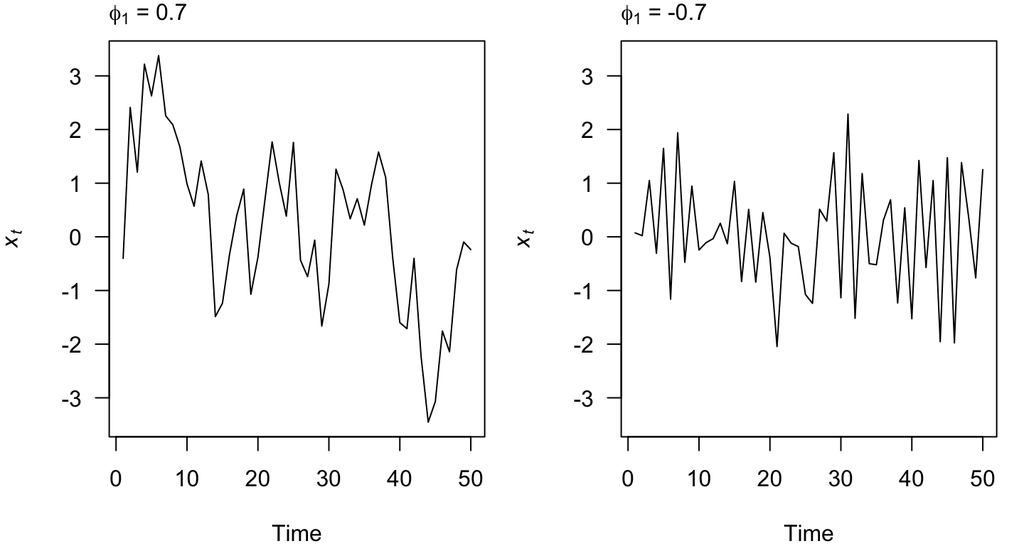

Same value, but different sign

## Coefficients of AR(1) models

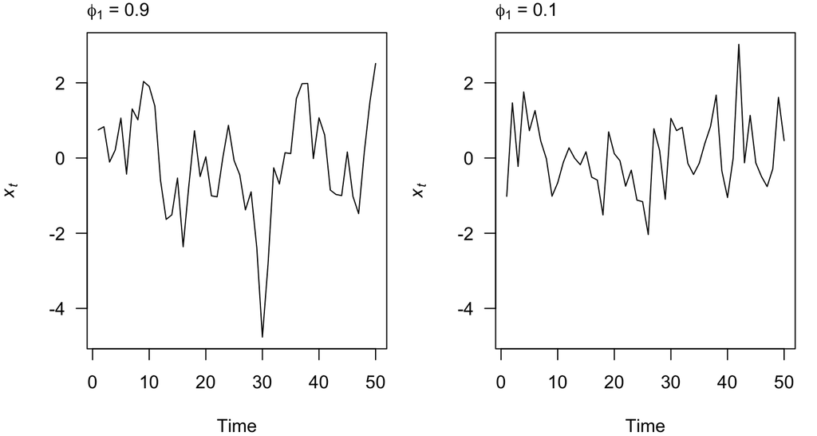

Both positive, but different magnitude

## Autocorrelation function (ACF)

Recall that the *autocorrelation function* (\(\rho_k\)) measures the correlation between \(\{x_t\}\) and a shifted version of itself \(\{x_{t+k}\}\)

## ACF for AR(1) models

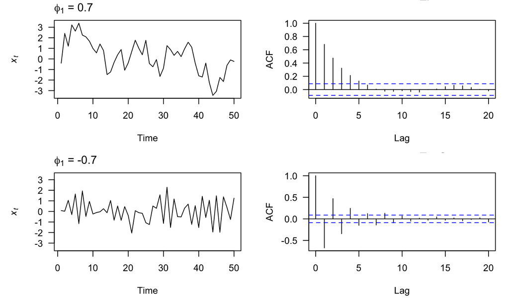

ACF oscillates for model with \(-\phi\)

## ACF for AR(1) models

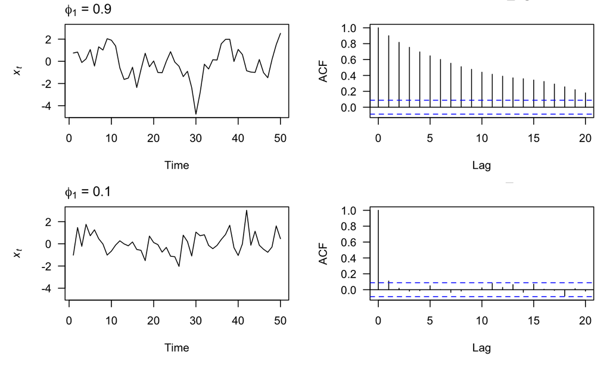

For model with large \(\phi\), ACF has longer tail

## Partial autocorrelation funcion (PACF)

Recall that the *partial autocorrelation function* (\(\phi_k\)) measures the correlation between \(\{x_t\}\) and a shifted version of itself \(\{x_{t+k}\}\), with the linear dependence of \(\{x_{t-1},x_{t-2},\dots,x_{t-k-1}\}\) removed

## ACF & PACF for AR(*p*) models

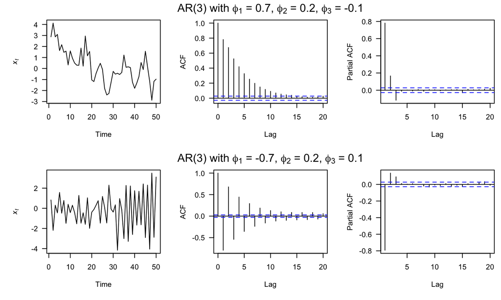

## PACF for AR(*p*) models

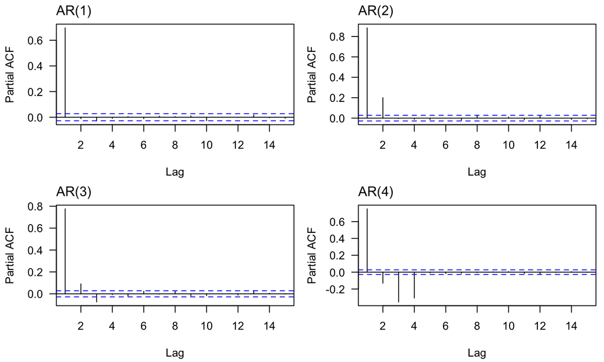

Do you see the link between the order *p* and lag *k*?

## Using ACF & PACF for model ID

| Model | ACF | PACF |
| --- | --- | --- |
| AR(*p*) | Tails off slowly | Cuts off after lag *p* |

## Moving average (MA) models

Moving average models are most commonly used for forecasting a future state

## Moving average (MA) models

A moving average model of order *q*, or MA(*q*), is defined as

\[ x_t = w_t + \theta_1 w_{t-1} + \theta_2 w_{t-2} + \dots + \theta_q w_{t-q} \]

where \(w_t\) is white noise

Each of the \(x_t\) is a sum of the most recent error terms

## Moving average (MA) models

A moving average model of order *q*, or MA(*q*), is defined as

\[ x_t = w_t + \theta_1 w_{t-1} + \theta_2 w_{t-2} + \dots + \theta_q w_{t-q} \]

where \(w_t\) is white noise

Each of the \(x_t\) is a sum of the most recent error terms

Thus, *all* MA processes are stationary because they are finite sums of stationary WN processes

## Examples of MA(*q*) models

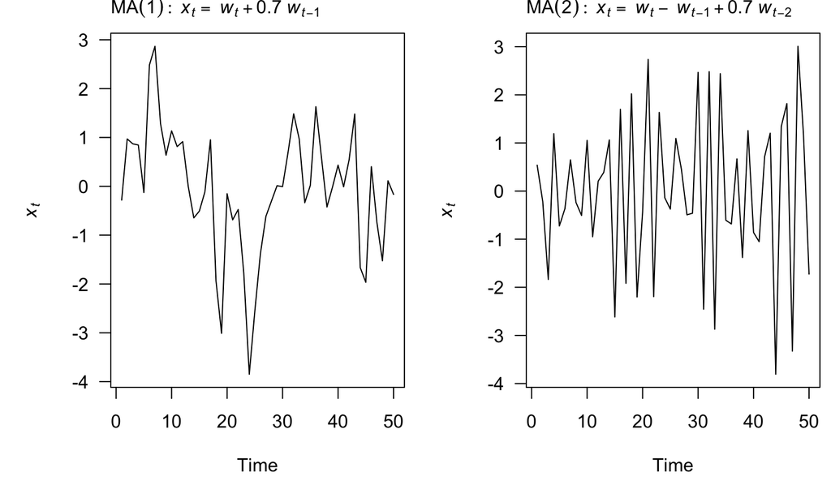

## ACF & PACF for MA(*q*) models

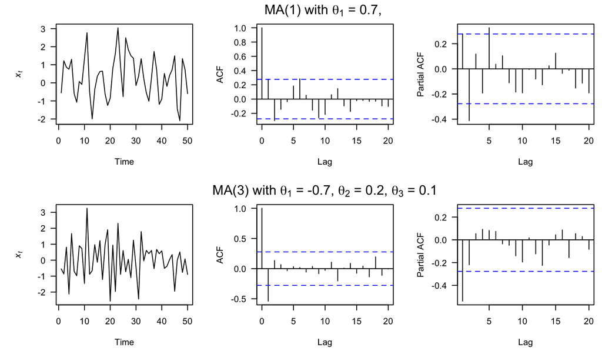

## ACF for MA(*q*) models

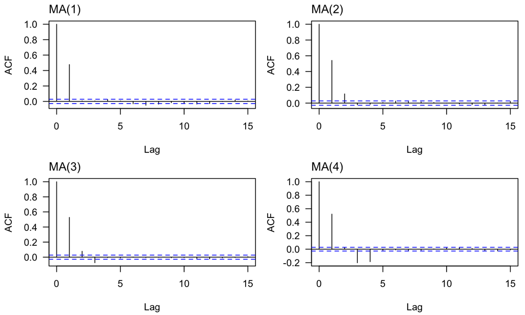

Do you see the link between the order *q* and lag *k*?

## Using ACF & PACF for model ID

| Model | ACF | PACF |
| --- | --- | --- |
| AR(*p*) | Tails off slowly | Cuts off after lag *p* |
| MA(*q*) | Cuts off after lag *q* | Tails off slowly |

## AR(*p*) model as an MA(\(\infty\)) model

It is possible to write an AR(*p*) model as an MA(\(\infty\)) model

## AR(1) model as an MA(\(\infty\)) model

For example, consider an AR(1) model

\[ x_t = \phi x_{t-1} + w_t \\ \]

## AR(1) model as an MA(\(\infty\)) model

For example, consider an AR(1) model

\[ x_t = \phi x_{t-1} + w_t \\ \Downarrow \\ x_{t-1} = \phi x_{t-2} + w_{t-1} \\ \Downarrow \\ x_{t-2} = \phi x_{t-3} + w_{t-2} \\ \Downarrow \\ x_{t-3} = \phi x_{t-4} + w_{t-3} \\ \]

## AR(1) model as an MA(\(\infty\)) model

Substituting in the expression for \(x_{t-1}\) into that for \(x_t\)

\[ x_t = \phi x_{t-1} + w_t \\ \Downarrow \\ x_{t-1} = \phi x_{t-2} + w_{t-1} \\ \Downarrow \\ x_t = \phi (\phi x_{t-2} + w_{t-1}) + w_t \\ x_t = \phi^2 x_{t-2} + \phi w_{t-1} + w_t \]

## AR(1) model as an MA(\(\infty\)) model

And repeated substitutions yields

\[ \begin{align} x_t &= \phi^2 x_{t-2} + \phi w_{t-1} + w_t \\ & \Downarrow \\ x_t &= \phi^3 x_{t-3} + \phi^2 w_{t-2} + \phi w_{t-1} + w_t \\ & \Downarrow \\ x_t &= \phi^4 x_{t-4} + \phi^3 w_{t-3} + \phi^2 w_{t-2} + \phi w_{t-1} + w_t \\ & \Downarrow \\ x_t &= w_t + \phi w_{t-1}+ \phi^2 w_{t-2} + \dots + \phi^k w_{t-k} + \phi^{k+1} x_{t-k-1} \end{align} \]

## AR(1) model as an MA(\(\infty\)) model

If our AR(1) model is stationary, then

\[ \lvert \phi \rvert < 1 \]

which then implies that

\[ \lim_{k \to \infty} \phi^{k+1} = 0 \]

## AR(1) model as an MA(\(\infty\)) model

If our AR(1) model is stationary, then

\[ \lvert \phi \rvert < 1 \]

which then implies that

\[ \lim_{k \to \infty} \phi^{k+1} = 0 \]

and hence

\[ \begin{align} x_t &= w_t + \phi w_{t-1}+ \phi^2 w_{t-2} + \dots + \phi^k w_{t-k} + \phi^{k+1} x_{t-k-1} \\ & \Downarrow \\ x_t &= w_t + \phi w_{t-1}+ \phi^2 w_{t-2} + \dots + \phi^k w_{t-k} \end{align} \]

## Invertible MA(*q*) models

An MA(*q*) process is *invertible* if it can be written as a stationary autoregressive process of infinite order without an error term

\[ x_t = w_t + \theta_1 w_{t-1} + \theta_2 w_{t-2} + \dots + \theta_q w_{t-q} \\ \Downarrow ? \\ w_t = x_t + \sum_{k=1}^\infty(-\theta)^k x_{t-k} \]

## Invertible MA(*q*) models

Q: Why do we care if an MA(*q*) model is invertible?

A: It helps us identify the model’s parameters

## Invertible MA(*q*) models

For example, these MA(1) models are equivalent

\[ x_t = w_t + \frac{1}{5} w_{t-1} ~\text{with} ~w_t \sim ~\text{N}(0,25) \\ \Updownarrow \\ x_t = w_t + 5 w_{t-1} ~\text{with} ~w_t \sim ~\text{N}(0,1) \]

## Variance of an MA(1) model

The variance of \(x_t\) is given by

\[ x_t = w_t + \frac{1}{5} w_{t-1} ~\text{with} ~w_t \sim ~\text{N}(0,25) \\ \Downarrow \\ \begin{align} \text{Var}(x_t) &= \text{Var}(w_t) + \left( \frac{1}{25} \right) \text{Var}(w_{t-1}) \\ &= 25 + \left( \frac{1}{25} \right) 25 \\ &= 25 + 1 \\ &= 26 \end{align} \]

## Variance of an MA(1) model

The variance of \(x_t\) is given by

\[ x_t = w_t + 5 w_{t-1} ~\text{with} ~w_t \sim ~\text{N}(0,1) \\ \Downarrow \\ \begin{align} \text{Var}(x_t) &= \text{Var}(w_t) + (25) \text{Var}(w_{t-1}) \\ &= 1 + (25) 1 \\ &= 1 + 25 \\ &= 26 \end{align} \]

## Rewriting an MA(1) model

We can rewrite an MA(1) model in terms of \(x\)

\[ x_t = w_t + \theta w_{t-1} \\ \Downarrow \\ w_t = x_t - \theta w_{t-1} \\ \]

## Rewriting an MA(1) model

And now we can substitute in previous expressions for \(w_t\)

\[ \begin{align} w_t &= x_t - \theta w_{t-1} \\ & \Downarrow \\ w_{t-1} &= x_{t-1} - \theta w_{t-2} \\ & \Downarrow \\ w_t &= x_t - \theta (x_{t-1} - \theta w_{t-2}) \\ w_t &= x_t - \theta x_{t-1} - \theta^2 w_{t-2} \\ & ~~\vdots \\ w_t &= x_t - \theta x_{t-1} - \dots -\theta^k x_{t-k} -\theta^{k+1} w_{t-k-1} \\ \end{align} \]

## Invertible MA(1) model

If we constrain \(\lvert \theta \rvert < 1\), then

\[ \lim_{k \to \infty} (-\theta)^{k+1} w_{t-k-1} = 0 \]

and

\[ \begin{align} w_t &= x_t - \theta x_{t-1} - \dots -\theta^k x_{t-k} -\theta^{k+1} w_{t-k-1} \\ & \Downarrow \\ w_t &= x_t - \theta x_{t-1} - \dots -\theta^k x_{t-k} \\ w_t &= x_t + \sum_{k=1}^\infty(-\theta)^k x_{t-k} \end{align} \]

## Autoregressive moving average models

An autoregressive moving average, or ARMA(*p*,*q*), model is written as

\[ x_t = \phi_1 x_{t-1} + \dots + \phi_p x_{t-p} + w_t + \theta_1 w_{t-1} + \dots + \theta_q w_{t-q} \]

## Autoregressive moving average models

We can write an ARMA(*p*,*q*) model using the backshift operator

\[ \phi_p (\mathbf{B}^p) x_t= \theta_q (\mathbf{B}^q) w_t \]

## Autoregressive moving average models

We can write an ARMA(*p*,*q*) model using the backshift operator

\[ \phi_p (\mathbf{B}^p) x_t= \theta_q (\mathbf{B}^q) w_t \]

ARMA models are *stationary* if all roots of \(\phi_p (\mathbf{B}) > 1\)

ARMA models are *invertible* if all roots of \(\theta_q (\mathbf{B}) > 1\)

## Examples of ARMA(*p*,*q*) models

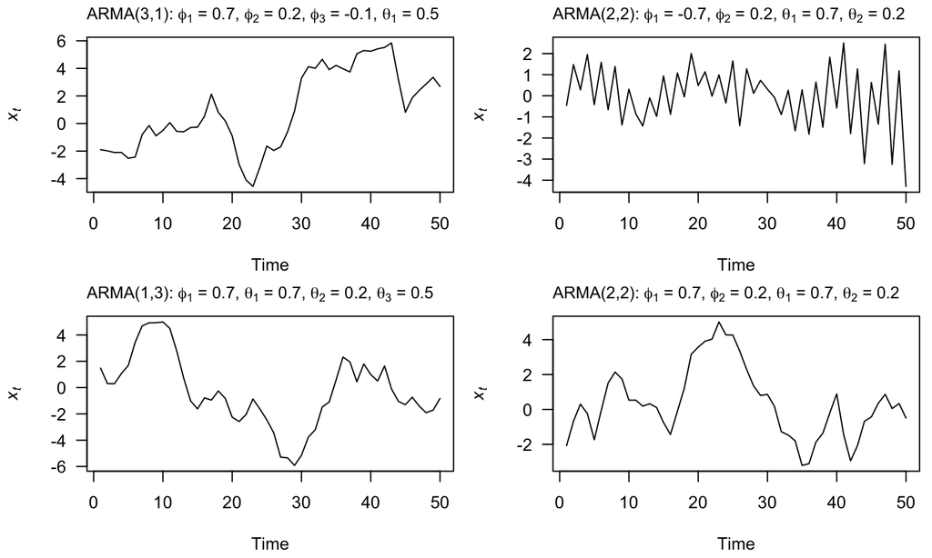

## ACF for ARMA(*p*,*q*) models

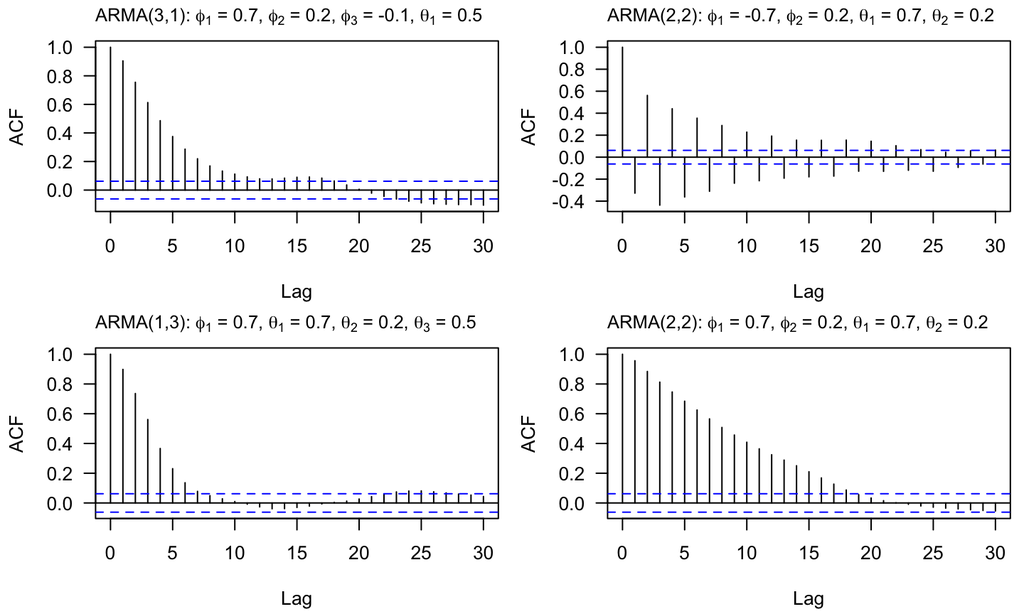

## PACF for ARMA(*p*,*q*) models

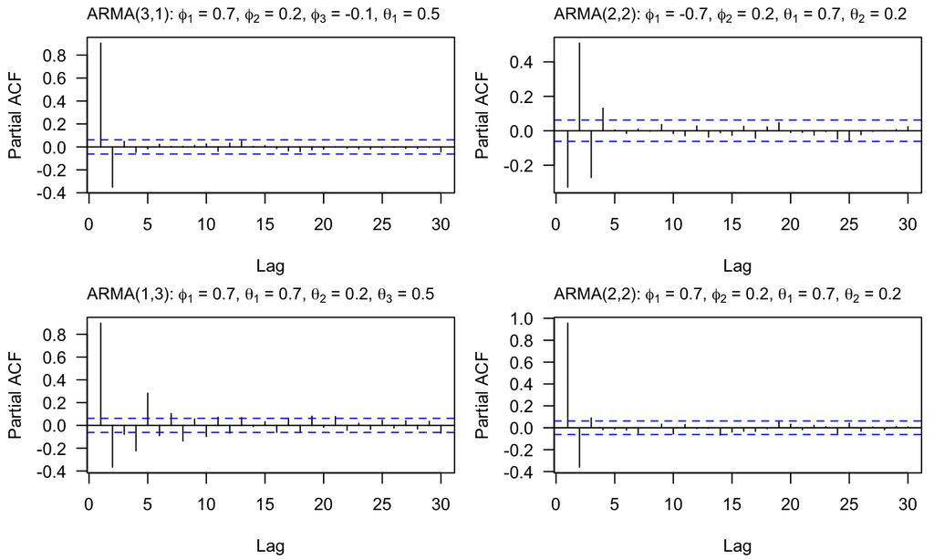

## Using ACF & PACF for model ID

| Model | ACF | PACF |
| --- | --- | --- |
| AR(*p*) | Tails off slowly | Cuts off after lag *p* |
| MA(*q*) | Cuts off after lag *q* | Tails off slowly |
| ARMA(*p*,*q*) | Tails off slowly | Tails off slowly |

NONSTATIONARY MODELS

## Autoregressive integrated moving average (ARIMA) models

If the data do not appear stationary, differencing can help

This leads to the class of *autoregressive integrated moving average* (ARIMA) models

ARIMA models are indexed with orders (*p*,*d*,*q*) where *d* indicates the order of differencing

## ARIMA(*p*,*d*,*q*) models

### Definition

\(\{x_t\}\) follows an ARIMA(*p*,*d*,*q*) process if \((1-\mathbf{B})^d x_t\) is an ARMA(*p*,*q*) process

## ARIMA(*p*,*d*,*q*) models

### An example

Consider an ARMA(1,0) = AR(1) process where

\[ x_t = (1 + \phi) x_{t-1} + w_t \]

## ARIMA(*p*,*d*,*q*) models

### An example

Consider an ARMA(1,0) = AR(1) process where

\[ x_t = (1 + \phi) x_{t-1} + w_t \\ \Downarrow \\ \begin{align} x_t &= x_{t-1} + \phi x_{t-1} + w_t \\ x_t - x_{t-1} &= \phi x_{t-1} + w_t \\ (1-\mathbf{B}) x_t &= \phi x_{t-1} + w_t \end{align} \]

So \({x_t}\) is indeed an ARIMA(1,1,0) process

## ARIMA(*p*,*d*,*q*) models

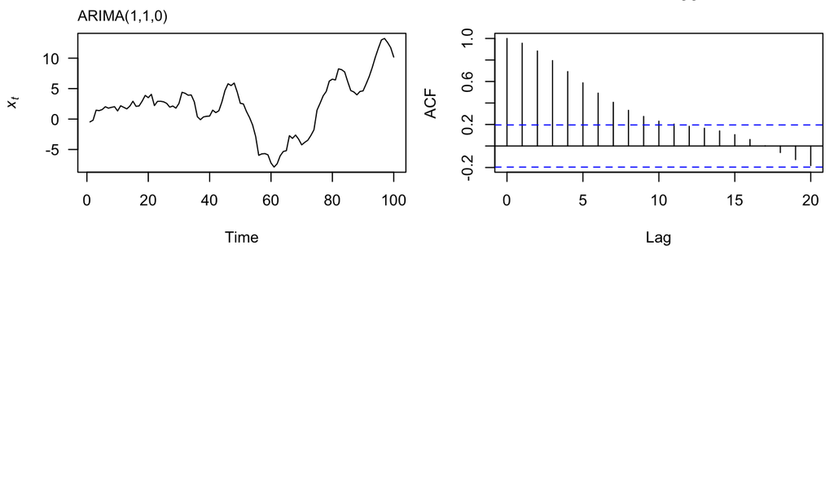

## ARIMA(*p*,*d*,*q*) models

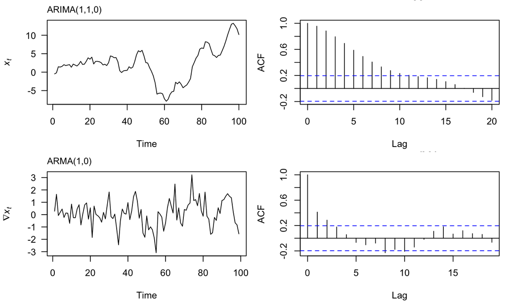

## Topics for today

Review

- White noise
- Random walks

Autoregressive (AR) models

Moving average (MA) models

Autoregressive moving average (ARMA) models

Using ACF & PACF for model ID